# Kelompok

# Packages

```r
library(stringr)
library(dplyr)
library(tidyverse)
library(skimr)
library(VIM)
library(performanceEstimation)
library(caret)
library(ranger)
library(gbm)
library(MLmetrics)
library(lime)
```

```r
library(cowplot)
library(randomForest)
library(vcdExtra)
library(UBL)
library(ggplot2)
library(readxl)
library("imbalance")
```

# Input Data

```r
gym <- read_xlsx("D:/Semester 5/PSD/Proyek UAS/data_gym.xlsx")
str(gym)
```

```
## tibble [973 × 15] (S3: tbl_df/tbl/data.frame)
##  $ Age                          : num [1:973] 56 46 32 25 38 56 36 40 28 28 ...
##  $ Gender                       : chr [1:973] "Male" "Female" "Female" "Male" ...
##  $ Weight (kg)                  : num [1:973] 88.3 74.9 68.1 53.2 46.1 ...
##  $ Height (m)                   : num [1:973] 1.71 1.53 1.66 1.7 1.79 1.68 1.72 1.51 1.94 1.84 ...
##  $ Max_BPM                      : num [1:973] 180 179 167 190 188 168 174 189 185 169 ...
##  $ Avg_BPM                      : num [1:973] 157 151 122 164 158 156 169 141 127 136 ...
##  $ Resting_BPM                  : num [1:973] 60 66 54 56 68 74 73 64 52 64 ...
##  $ Session_Duration (hours)     : num [1:973] 1.69 1.3 1.11 0.59 0.64 1.59 1.49 1.27 1.03 1.08 ...
##  $ Calories_Burned              : num [1:973] 1313 883 677 532 556 ...
##  $ Workout_Type                 : chr [1:973] "Yoga" "HIIT" "Cardio" "Strength" ...
##  $ Fat_Percentage               : num [1:973] 12.6 33.9 33.4 28.8 29.2 15.5 21.3 30.6 28.9 29.7 ...
##  $ Water_Intake (liters)        : num [1:973] 3.5 2.1 2.3 2.1 2.8 2.7 2.3 1.9 2.6 2.7 ...
##  $ Workout_Frequency (days/week): num [1:973] 4 4 4 3 3 5 3 3 4 3 ...
##  $ Experience_Level             : num [1:973] 3 2 2 1 1 3 2 2 2 1 ...
##  $ BMI                          : num [1:973] 30.2 32 24.7 18.4 14.4 ...
```

```r
library(dplyr)

gym <- gym %>%
  mutate(Experience_Level = recode(Experience_Level,
    `1` = "Beginner",
    `2` = "Intermediate",
    `3` = "Expert"
  ))
str(gym)
```

```
## tibble [973 × 15] (S3: tbl_df/tbl/data.frame)
##  $ Age                          : num [1:973] 56 46 32 25 38 56 36 40 28 28 ...
##  $ Gender                       : chr [1:973] "Male" "Female" "Female" "Male" ...
##  $ Weight (kg)                  : num [1:973] 88.3 74.9 68.1 53.2 46.1 ...
##  $ Height (m)                   : num [1:973] 1.71 1.53 1.66 1.7 1.79 1.68 1.72 1.51 1.94 1.84 ...
##  $ Max_BPM                      : num [1:973] 180 179 167 190 188 168 174 189 185 169 ...
##  $ Avg_BPM                      : num [1:973] 157 151 122 164 158 156 169 141 127 136 ...
##  $ Resting_BPM                  : num [1:973] 60 66 54 56 68 74 73 64 52 64 ...
##  $ Session_Duration (hours)     : num [1:973] 1.69 1.3 1.11 0.59 0.64 1.59 1.49 1.27 1.03 1.08 ...
##  $ Calories_Burned              : num [1:973] 1313 883 677 532 556 ...
##  $ Workout_Type                 : chr [1:973] "Yoga" "HIIT" "Cardio" "Strength" ...
##  $ Fat_Percentage               : num [1:973] 12.6 33.9 33.4 28.8 29.2 15.5 21.3 30.6 28.9 29.7 ...
##  $ Water_Intake (liters)        : num [1:973] 3.5 2.1 2.3 2.1 2.8 2.7 2.3 1.9 2.6 2.7 ...
##  $ Workout_Frequency (days/week): num [1:973] 4 4 4 3 3 5 3 3 4 3 ...
##  $ Experience_Level             : chr [1:973] "Expert" "Intermediate" "Intermediate" "Beginner" ...
##  $ BMI                          : num [1:973] 30.2 32 24.7 18.4 14.4 ...
```

**Keterangan data di kaggle**

Usia: Usia anggota gym.

Jenis kelamin: Jenis kelamin anggota gym (Pria atau Wanita).

Berat (kg): Berat anggota dalam kilogram.

Tinggi (m): Tinggi anggota dalam meter.

Max_BPM: Detak jantung maksimum (detak per menit) selama sesi latihan.

Avg_BPM: Detak jantung rata-rata selama sesi latihan.

Resting_BPM: Detak jantung saat istirahat sebelum berolahraga.

Session_Duration (jam): Durasi setiap sesi olahraga dalam jam.

Calories_Burned: Total kalori yang terbakar selama setiap sesi.

Workout_Type: Jenis latihan yang dilakukan (misalnya, Kardio, Kekuatan, Yoga, HIIT).

Fat_Percentage: Persentase lemak tubuh anggota.

Water_Intake (liter): Asupan air setiap hari selama berolahraga.

Workout_Frequency (hari/minggu): Jumlah sesi olahraga per minggu.

Experience_Level: Tingkat pengalaman, dari pemula (1) hingga ahli (3).

BMI: Indeks Massa Tubuh, dihitung dari tinggi dan berat badan.

```r
# Mengubah tipe data dalam tibble sesuai spesifikasi
gym <- gym %>%
  mutate(Gender = as.factor(Gender),
         Workout_Type = as.factor(Workout_Type),
         Experience_Level = as.factor( Experience_Level))


# Untuk memeriksa hasil perubahan tipe data
str(gym)
```

```
## tibble [973 × 15] (S3: tbl_df/tbl/data.frame)
##  $ Age                          : num [1:973] 56 46 32 25 38 56 36 40 28 28 ...
##  $ Gender                       : Factor w/ 2 levels "Female","Male": 2 1 1 2 2 1 2 1 2 2 ...
##  $ Weight (kg)                  : num [1:973] 88.3 74.9 68.1 53.2 46.1 ...
##  $ Height (m)                   : num [1:973] 1.71 1.53 1.66 1.7 1.79 1.68 1.72 1.51 1.94 1.84 ...
##  $ Max_BPM                      : num [1:973] 180 179 167 190 188 168 174 189 185 169 ...
##  $ Avg_BPM                      : num [1:973] 157 151 122 164 158 156 169 141 127 136 ...
##  $ Resting_BPM                  : num [1:973] 60 66 54 56 68 74 73 64 52 64 ...
##  $ Session_Duration (hours)     : num [1:973] 1.69 1.3 1.11 0.59 0.64 1.59 1.49 1.27 1.03 1.08 ...
##  $ Calories_Burned              : num [1:973] 1313 883 677 532 556 ...
##  $ Workout_Type                 : Factor w/ 4 levels "Cardio","HIIT",..: 4 2 1 3 3 2 1 1 3 1 ...
##  $ Fat_Percentage               : num [1:973] 12.6 33.9 33.4 28.8 29.2 15.5 21.3 30.6 28.9 29.7 ...
##  $ Water_Intake (liters)        : num [1:973] 3.5 2.1 2.3 2.1 2.8 2.7 2.3 1.9 2.6 2.7 ...
##  $ Workout_Frequency (days/week): num [1:973] 4 4 4 3 3 5 3 3 4 3 ...
##  $ Experience_Level             : Factor w/ 3 levels "Beginner","Expert",..: 2 3 3 1 1 2 3 3 3 1 ...
##  $ BMI                          : num [1:973] 30.2 32 24.7 18.4 14.4 ...
```

```r
gym <-data.frame(gym)
str(gym)
```

```
## 'data.frame':    973 obs. of  15 variables:
##  $ Age                          : num  56 46 32 25 38 56 36 40 28 28 ...
##  $ Gender                       : Factor w/ 2 levels "Female","Male": 2 1 1 2 2 1 2 1 2 2 ...
##  $ Weight..kg.                  : num  88.3 74.9 68.1 53.2 46.1 ...
##  $ Height..m.                   : num  1.71 1.53 1.66 1.7 1.79 1.68 1.72 1.51 1.94 1.84 ...
##  $ Max_BPM                      : num  180 179 167 190 188 168 174 189 185 169 ...
##  $ Avg_BPM                      : num  157 151 122 164 158 156 169 141 127 136 ...
##  $ Resting_BPM                  : num  60 66 54 56 68 74 73 64 52 64 ...
##  $ Session_Duration..hours.     : num  1.69 1.3 1.11 0.59 0.64 1.59 1.49 1.27 1.03 1.08 ...
##  $ Calories_Burned              : num  1313 883 677 532 556 ...
##  $ Workout_Type                 : Factor w/ 4 levels "Cardio","HIIT",..: 4 2 1 3 3 2 1 1 3 1 ...
##  $ Fat_Percentage               : num  12.6 33.9 33.4 28.8 29.2 15.5 21.3 30.6 28.9 29.7 ...
##  $ Water_Intake..liters.        : num  3.5 2.1 2.3 2.1 2.8 2.7 2.3 1.9 2.6 2.7 ...
##  $ Workout_Frequency..days.week.: num  4 4 4 3 3 5 3 3 4 3 ...
##  $ Experience_Level             : Factor w/ 3 levels "Beginner","Expert",..: 2 3 3 1 1 2 3 3 3 1 ...
##  $ BMI                          : num  30.2 32 24.7 18.4 14.4 ...
```

# Eksplorasi Data

```r
skimr::skim(gym)
```

Data summary

| Name | gym |
| --- | --- |
| Number of rows | 973 |
| Number of columns | 15 |
| _______________________ |  |
| Column type frequency: |  |
| factor | 3 |
| numeric | 12 |
| ________________________ |  |
| Group variables | None |

**Variable type: factor**

| skim_variable | n_missing | complete_rate | ordered | n_unique | top_counts |
| --- | --- | --- | --- | --- | --- |
| Gender | 0 | 1 | FALSE | 2 | Mal: 511, Fem: 462 |
| Workout_Type | 0 | 1 | FALSE | 4 | Str: 258, Car: 255, Yog: 239, HII: 221 |
| Experience_Level | 0 | 1 | FALSE | 3 | Int: 406, Beg: 376, Exp: 191 |

**Variable type: numeric**

| skim_variable | n_missing | complete_rate | mean | sd | p0 | p25 | p50 | p75 | p100 | hist |
| --- | --- | --- | --- | --- | --- | --- | --- | --- | --- | --- |
| Age | 0 | 1 | 38.68 | 12.18 | 18.00 | 28.00 | 40.00 | 49.00 | 59.00 | ▇▆▇▇▇ |
| Weight..kg. | 0 | 1 | 73.85 | 21.21 | 40.00 | 58.10 | 70.00 | 86.00 | 129.90 | ▅▇▅▂▂ |
| Height..m. | 0 | 1 | 1.72 | 0.13 | 1.50 | 1.62 | 1.71 | 1.80 | 2.00 | ▅▇▇▃▃ |
| Max_BPM | 0 | 1 | 179.88 | 11.53 | 160.00 | 170.00 | 180.00 | 190.00 | 199.00 | ▇▇▇▇▇ |
| Avg_BPM | 0 | 1 | 143.77 | 14.35 | 120.00 | 131.00 | 143.00 | 156.00 | 169.00 | ▇▇▆▆▆ |
| Resting_BPM | 0 | 1 | 62.22 | 7.33 | 50.00 | 56.00 | 62.00 | 68.00 | 74.00 | ▇▆▇▇▇ |
| Session_Duration..hours. | 0 | 1 | 1.26 | 0.34 | 0.50 | 1.04 | 1.26 | 1.46 | 2.00 | ▂▅▇▃▂ |
| Calories_Burned | 0 | 1 | 905.42 | 272.64 | 303.00 | 720.00 | 893.00 | 1076.00 | 1783.00 | ▃▇▇▂▁ |
| Fat_Percentage | 0 | 1 | 24.98 | 6.26 | 10.00 | 21.30 | 26.20 | 29.30 | 35.00 | ▂▂▅▇▅ |
| Water_Intake..liters. | 0 | 1 | 2.63 | 0.60 | 1.50 | 2.20 | 2.60 | 3.10 | 3.70 | ▃▆▇▃▆ |
| Workout_Frequency..days.week. | 0 | 1 | 3.32 | 0.91 | 2.00 | 3.00 | 3.00 | 4.00 | 5.00 | ▅▇▁▆▂ |
| BMI | 0 | 1 | 24.91 | 6.66 | 12.32 | 20.11 | 24.16 | 28.56 | 49.84 | ▅▇▅▁▁ |

Berdasarkan data diatas, tidak terdapat missing value pada setiap variabel

```r
summary(gym)
```

```
##       Age           Gender     Weight..kg.       Height..m.       Max_BPM
##  Min.   :18.00   Female:462   Min.   : 40.00   Min.   :1.500   Min.   :160.0
##  1st Qu.:28.00   Male  :511   1st Qu.: 58.10   1st Qu.:1.620   1st Qu.:170.0
##  Median :40.00                Median : 70.00   Median :1.710   Median :180.0
##  Mean   :38.68                Mean   : 73.85   Mean   :1.723   Mean   :179.9
##  3rd Qu.:49.00                3rd Qu.: 86.00   3rd Qu.:1.800   3rd Qu.:190.0
##  Max.   :59.00                Max.   :129.90   Max.   :2.000   Max.   :199.0
##     Avg_BPM       Resting_BPM    Session_Duration..hours. Calories_Burned
##  Min.   :120.0   Min.   :50.00   Min.   :0.500            Min.   : 303.0
##  1st Qu.:131.0   1st Qu.:56.00   1st Qu.:1.040            1st Qu.: 720.0
##  Median :143.0   Median :62.00   Median :1.260            Median : 893.0
##  Mean   :143.8   Mean   :62.22   Mean   :1.256            Mean   : 905.4
##  3rd Qu.:156.0   3rd Qu.:68.00   3rd Qu.:1.460            3rd Qu.:1076.0
##  Max.   :169.0   Max.   :74.00   Max.   :2.000            Max.   :1783.0
##    Workout_Type Fat_Percentage  Water_Intake..liters.
##  Cardio  :255   Min.   :10.00   Min.   :1.500
##  HIIT    :221   1st Qu.:21.30   1st Qu.:2.200
##  Strength:258   Median :26.20   Median :2.600
##  Yoga    :239   Mean   :24.98   Mean   :2.627
##                 3rd Qu.:29.30   3rd Qu.:3.100
##                 Max.   :35.00   Max.   :3.700
##  Workout_Frequency..days.week.     Experience_Level      BMI
##  Min.   :2.000                 Beginner    :376     Min.   :12.32
##  1st Qu.:3.000                 Expert      :191     1st Qu.:20.11
##  Median :3.000                 Intermediate:406     Median :24.16
##  Mean   :3.322                                      Mean   :24.91
##  3rd Qu.:4.000                                      3rd Qu.:28.56
##  Max.   :5.000                                      Max.   :49.84
```

# Visualisasi Data

## Sebaran Peubah Kategorik

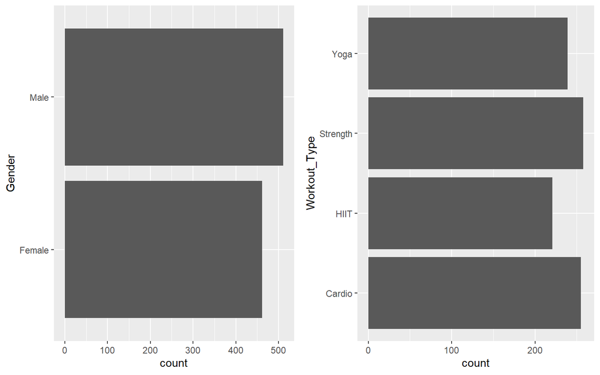

```r
count_categoric_features <- function(x){
  ggplot(gym, aes_string(x = x)) +
    geom_bar() +
    coord_flip()
}

plot_grid(
  count_categoric_features("Gender"),
  count_categoric_features("Workout_Type"))
```

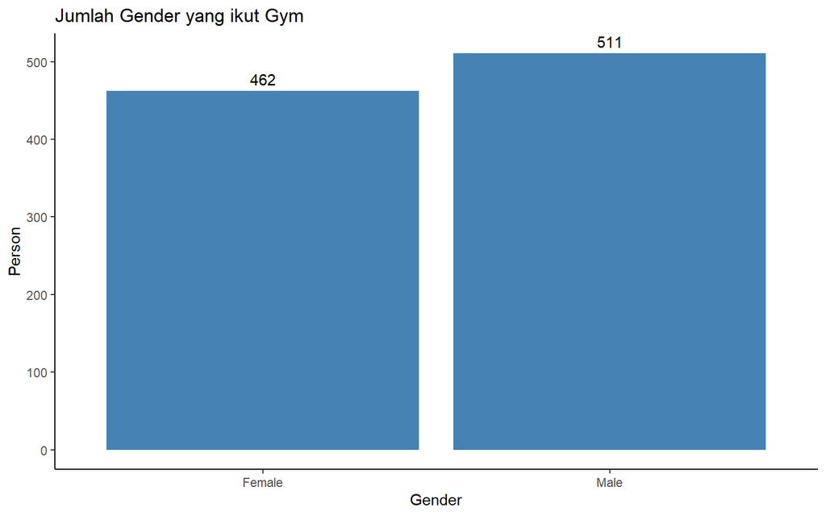

```r
library(ggplot2)

ggplot(gym, aes(x = Gender)) +
  geom_bar(fill = "steelblue") +
  geom_text(stat = "count", aes(label = ..count..), vjust = -0.5) +
  labs(title = "Jumlah Gender yang ikut Gym", x = "Gender", y = "Person") +
  theme_classic()
```

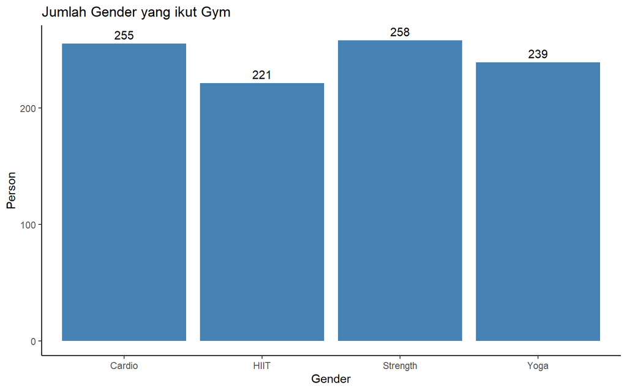

```r
library(ggplot2)

ggplot(gym, aes(x = Workout_Type)) +
  geom_bar(fill = "steelblue") +
  geom_text(stat = "count", aes(label = ..count..), vjust = -0.5) +
  labs(title = "Jumlah Gender yang ikut Gym", x = "Gender", y = "Person") +
  theme_classic()
```

## Sebaran Peubah Numerik

### Age

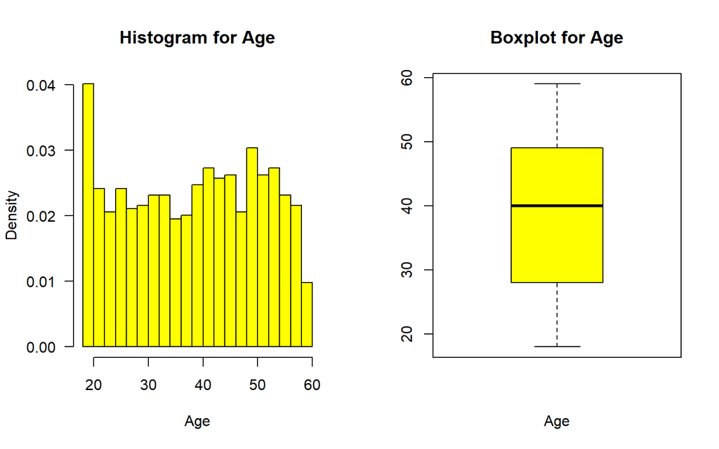

```r
par(mfrow=c(1,2))
hist(gym$Age,
     main="Histogram for Age",
     xlab="Age",
     border="black",
     col="yellow",
     las=1,
     breaks=20, prob = TRUE)
boxplot(gym$Age, col='yellow',xlab = 'Age', main = 'Boxplot for Age', outcol="red", pch=16)
```

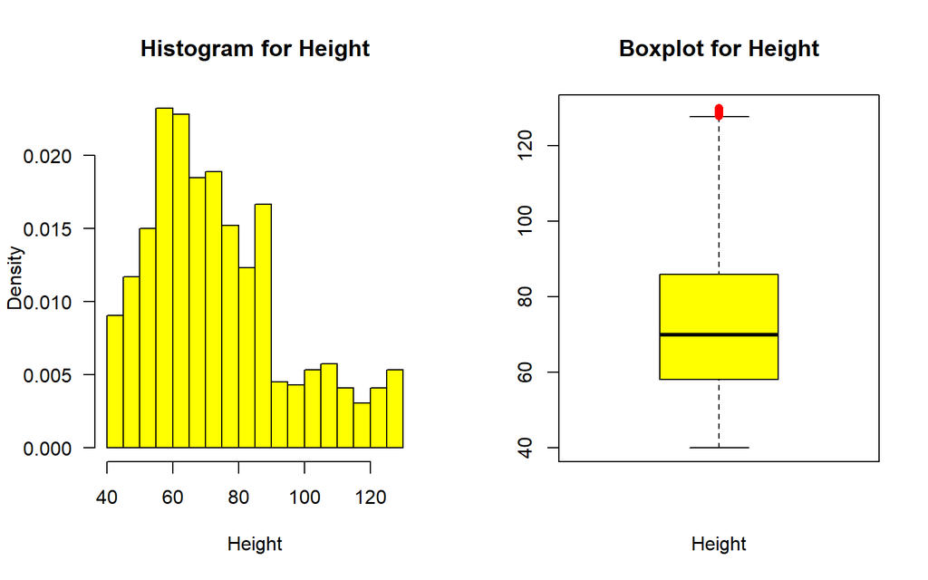

```r
par(mfrow=c(1,2))
hist(gym$Weight..kg.,
     main="Histogram for Height",
     xlab="Height",
     border="black",
     col="yellow",
     las=1,
     breaks=20, prob = TRUE)
boxplot(gym$Weight..kg., col='yellow',xlab = 'Height', main = 'Boxplot for Height', outcol="red", pch=16)
```

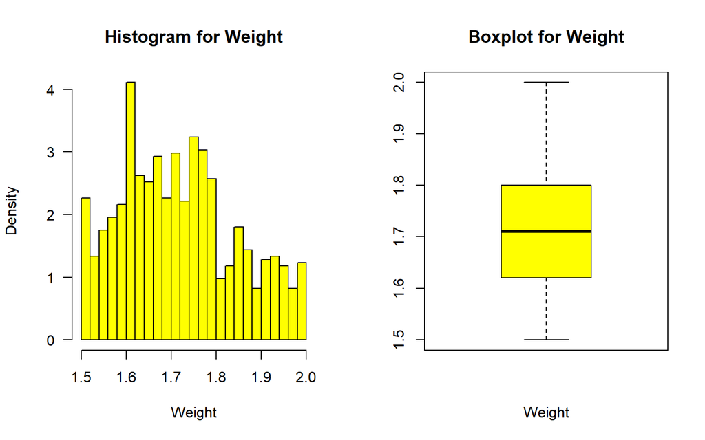

```r
par(mfrow=c(1,2))
hist(gym$Height..m.,
     main="Histogram for Weight",
     xlab="Weight",
     border="black",
     col="yellow",
     las=1,
     breaks=20, prob = TRUE)
boxplot(gym$Height..m., col='yellow',xlab = 'Weight', main = 'Boxplot for Weight', outcol="red", pch=16)
```

### MAX BPM

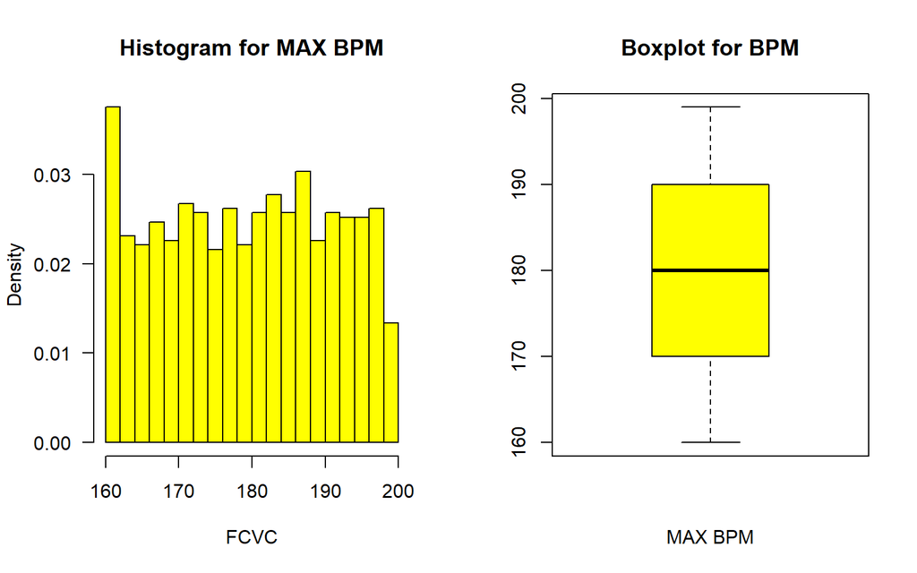

```r
par(mfrow=c(1,2))
hist(gym$Max_BPM,
     main="Histogram for MAX BPM",
     xlab="FCVC",
     border="black",
     col="yellow",
     las=1,
     breaks=20, prob = TRUE)
boxplot(gym$Max_BPM, col='yellow',xlab = 'MAX BPM', main = 'Boxplot for BPM', outcol="red", pch=16)
```

### AVG BPM

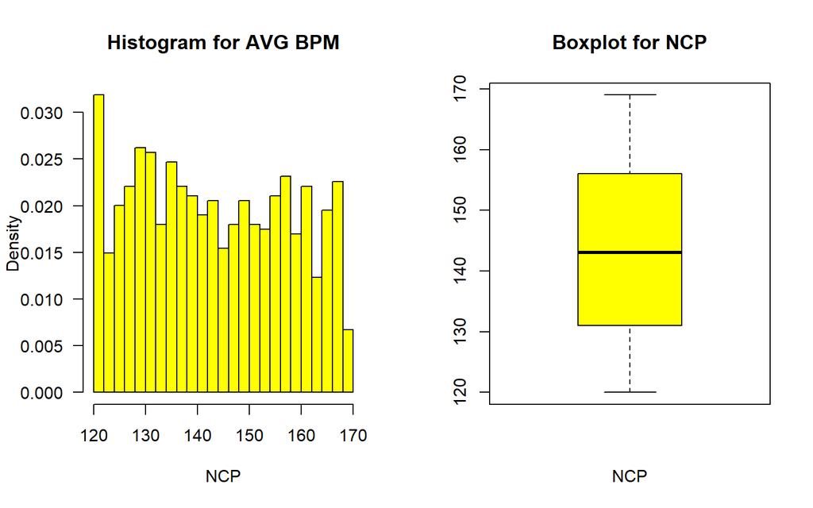

```r
par(mfrow=c(1,2))
hist(gym$Avg_BPM,
     main="Histogram for AVG BPM",
     xlab="NCP",
     border="black",
     col="yellow",
     las=1,
     breaks=20, prob = TRUE)
boxplot(gym$Avg_BPM, col='yellow',xlab = 'NCP', main = 'Boxplot for NCP', outcol="red", pch=16)
```

### Resting BPM

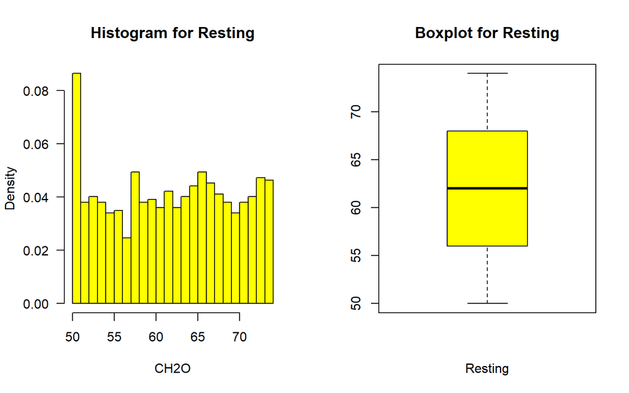

```r
par(mfrow=c(1,2))
hist(gym$Resting_BPM,
     main="Histogram for Resting",
     xlab="CH2O",
     border="black",
     col="yellow",
     las=1,
     breaks=20, prob = TRUE)
boxplot(gym$Resting_BPM, col='yellow',xlab = 'Resting', main = 'Boxplot for Resting', outcol="red", pch=16)
```

### Durasi

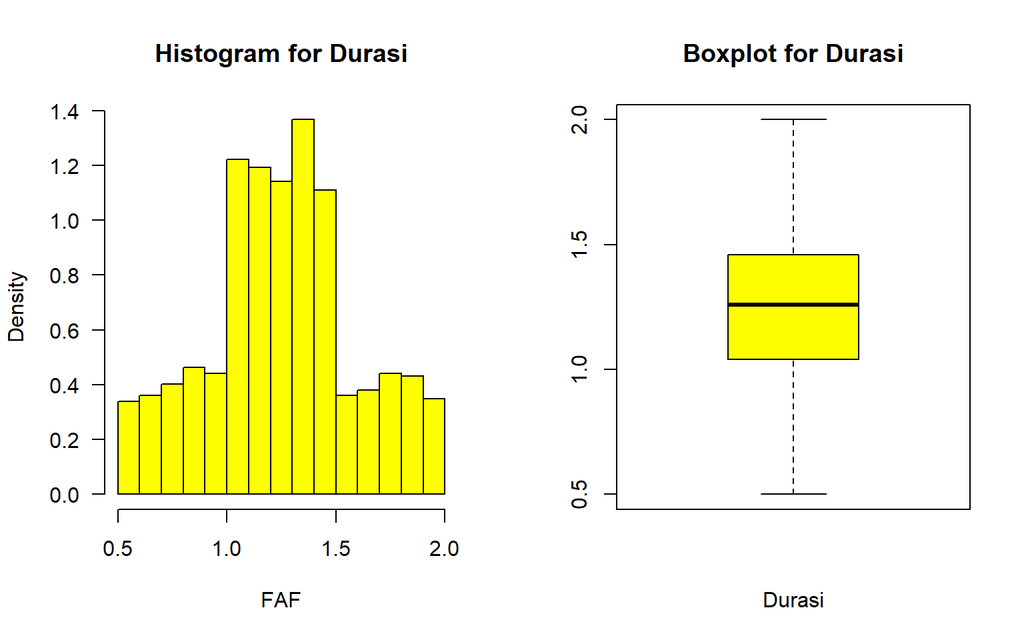

```r
par(mfrow=c(1,2))
hist(gym$Session_Duration..hours.,
     main="Histogram for Durasi",
     xlab="FAF",
     border="black",
     col="yellow",
     las=1,
     breaks=20, prob = TRUE)
boxplot(gym$Session_Duration..hours., col='yellow',xlab = 'Durasi', main = 'Boxplot for Durasi', outcol="red", pch=16)
```

### Kalori yang terbakar

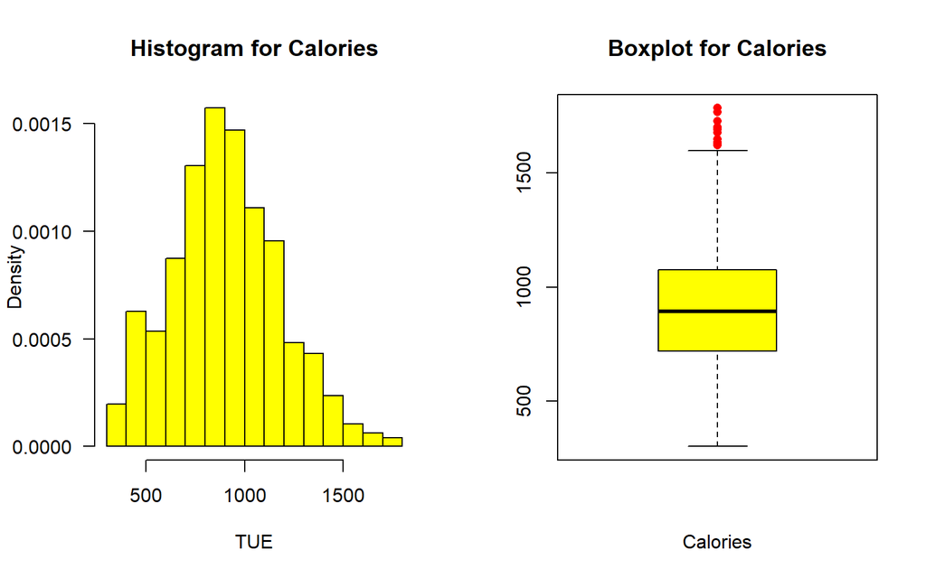

```r
par(mfrow=c(1,2))
hist(gym$Calories_Burned,
     main="Histogram for Calories",
     xlab="TUE",
     border="black",
     col="yellow",
     las=1,
     breaks=20, prob = TRUE)
boxplot(gym$Calories_Burned, col='yellow',xlab = 'Calories', main = 'Boxplot for Calories', outcol="red", pch=16)
```

### Fat_Percentage

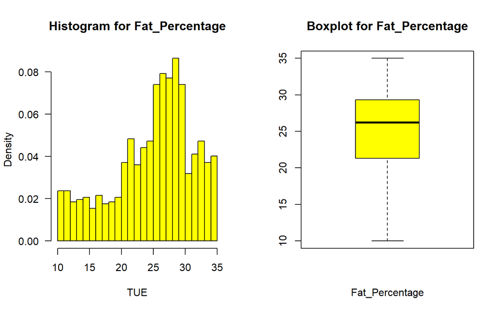

```r
par(mfrow=c(1,2))
hist(gym$Fat_Percentage,
     main="Histogram for Fat_Percentage",
     xlab="TUE",
     border="black",
     col="yellow",
     las=1,
     breaks=20, prob = TRUE)
boxplot(gym$Fat_Percentage, col='yellow',xlab = 'Fat_Percentage', main = 'Boxplot for Fat_Percentage', outcol="red", pch=16)
```

### Water_Intake..liters

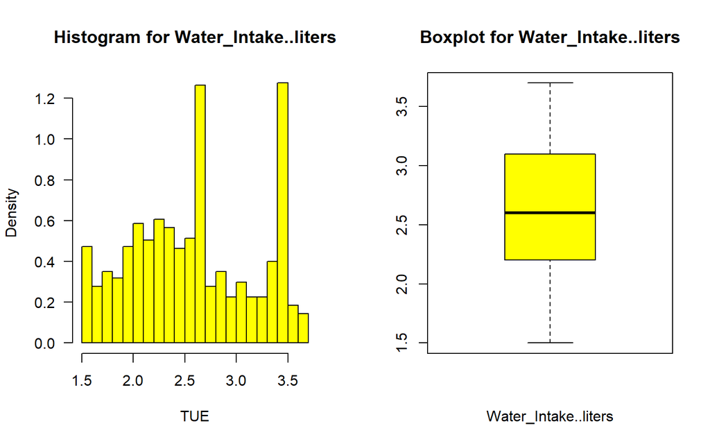

```r
par(mfrow=c(1,2))
hist(gym$Water_Intake..liters.,
     main="Histogram for Water_Intake..liters",
     xlab="TUE",
     border="black",
     col="yellow",
     las=1,
     breaks=20, prob = TRUE)
boxplot(gym$Water_Intake..liters., col='yellow',xlab = 'Water_Intake..liters', main = 'Boxplot for Water_Intake..liters', outcol="red", pch=16)
```

### Frekuensi Workout

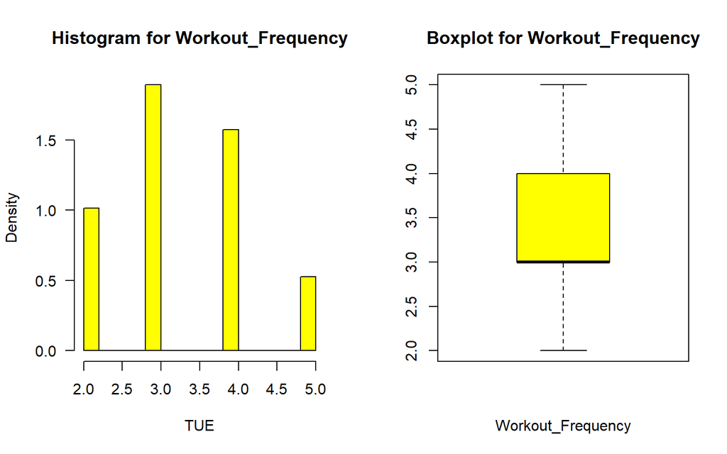

```r
par(mfrow=c(1,2))
hist(gym$Workout_Frequency..days.week.,
     main="Histogram for Workout_Frequency",
     xlab="TUE",
     border="black",
     col="yellow",
     las=1,
     breaks=20, prob = TRUE)
boxplot(gym$Workout_Frequency..days.week., col='yellow',xlab = 'Workout_Frequency', main = 'Boxplot for Workout_Frequency', outcol="red", pch=16)
```

### BMI

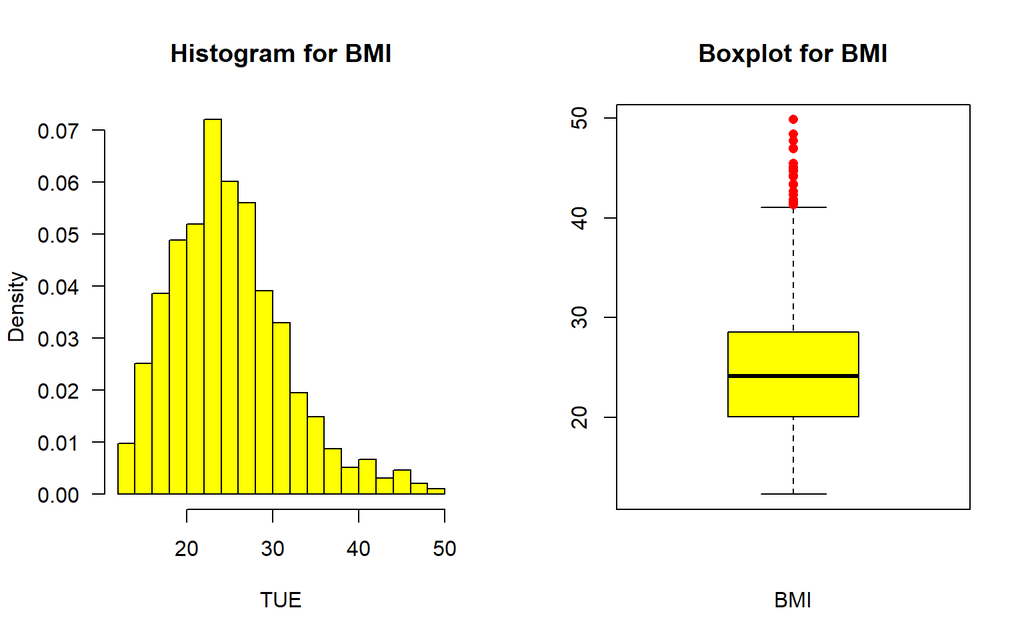

```r
par(mfrow=c(1,2))
hist(gym$BMI,
     main="Histogram for BMI",
     xlab="TUE",
     border="black",
     col="yellow",
     las=1,
     breaks=20, prob = TRUE)
boxplot(gym$BMI, col='yellow',xlab = 'BMI', main = 'Boxplot for BMI', outcol="red", pch=16)
```

## Sebaran Peubah Respon

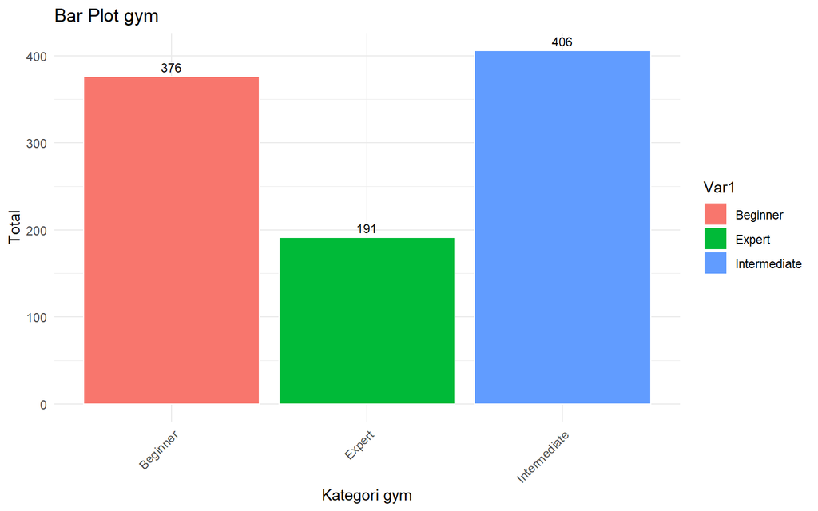

```r
table_gym <- table(gym$Experience_Level)
df_gym <- as.data.frame(table_gym)

bar.ploty <- ggplot(df_gym, aes(x = Var1, y = Freq, fill = Var1)) +
  geom_bar(stat = "identity", color = "white") +
  geom_text(aes(label = Freq), vjust = -0.5, size = 3) +
  theme_minimal() +
  labs(title = "Bar Plot gym", x = "Kategori gym", y = "Total") +
  theme(axis.text.x = element_text(angle = 45, hjust = 1))

bar.ploty
```

```r
#Imbalance Ratio
imbalanceRatio(gym, classAttr = "Experience_Level")
```

```
## [1] 0.2442455
```

```r
#Sebaran
table(gym$Experience_Level)
```

```
##
##     Beginner       Expert Intermediate
##          376          191          406
```

```r
prop.table(table(gym$Experience_Level))
```

```
##
##     Beginner       Expert Intermediate
##    0.3864337    0.1963001    0.4172662
```

## Analisis Korelasi

```r
# Memuat paket reshape2
library(reshape2)
```

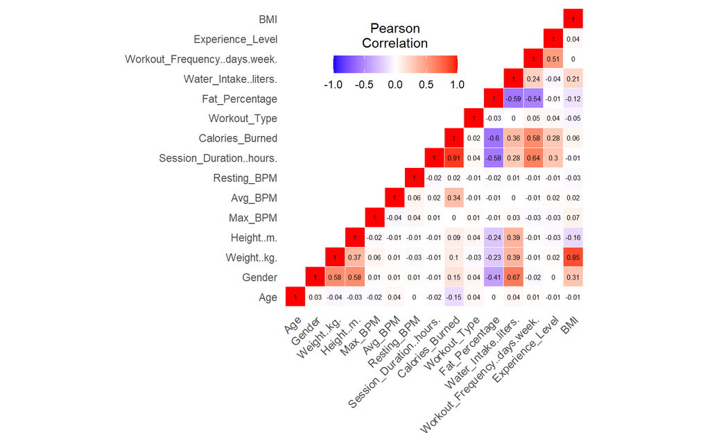

```r
cordata <- data.matrix(gym)
cormat <- round(cor(cordata, method = "pearson"),2)
melted_cormat <- melt(cormat)

# Peroleh segitiga atas dari matriks korelasi
get_upper_tri <- function(cormat){
  cormat[lower.tri(cormat)]<- NA
  return(cormat)
}

upper_tri <- get_upper_tri(cormat)

# Atur matriks korelasi
melted_cormat <- melt(upper_tri, na.rm = TRUE)

# Buat ggheatmap
ggheatmap <- ggplot(melted_cormat, aes(Var2, Var1, fill = value))+
  geom_tile(color = "white")+
  scale_fill_gradient2(low = "blue", high = "red", mid = "white",
                       midpoint = 0, limit = c(-1,1), space = "Lab",
                       name="Pearson\nCorrelation") +
  theme_minimal()+ # minimal theme
  theme(axis.text.x = element_text(angle = 45, vjust = 1,
                                   size = 9, hjust = 1))+
  coord_fixed()

ggheatmap +
  geom_text(aes(Var2, Var1, label = value), color = "black", size = 2) +
  theme(
    axis.title.x = element_blank(),
    axis.title.y = element_blank(),
    panel.grid.major = element_blank(),
    panel.border = element_blank(),
    panel.background = element_blank(),
    axis.ticks = element_blank(),
    legend.justification = c(1, 0),
    legend.position = c(0.6, 0.7),
    legend.direction = "horizontal")+
  guides(fill = guide_colorbar(barwidth = 7, barheight = 1,
                               title.position = "top", title.hjust = 0.5))
```

Frekuensi Workout memiliki korelasi terbesar dengan peubah respon

```r
gym <- gym %>%
  select(-Max_BPM)
```

# Splitting Data

```r
set.seed(123)
train_idx <- createDataPartition(gym$Experience_Level, p = 0.8, list=FALSE)
trainData <- gym[train_idx,]
testData <- gym[-train_idx,]
```

# Modeling

K-fold cross validation adalah salah satu teknik validasi untuk mencari tuning parameter terbaik sekaligus mengevaluasi kinerja model. Pada studi kasus ini digunakan 5-fold cross validation. Data dipartisi secara acak ke dalam lima subset data. Secara bergantian masing-masing subset akan dijadikan sebagai data testing, sementara empat subset data lainnya sebagai data training.

Pemodelan dilakukan dengan mencari Tuning Parameter dengan tuneLength. Opsi tuneLength ini akan memilih sejumlah tuning parameter atau kombinasi tuning parameter yang dianggap paling tepat sesuai dengan metode yang dipilih dan data training yang diberikan.

```r
set.seed(123)
fitControl <- trainControl(
  method = "cv",
  number = 5,
  returnResamp = "all")
```

# Random Forest

## Tanpa Penanganan

### Cross Validation

```r
set.seed(123)
random_forest <- train(Experience_Level~ .,
            data = trainData,
            method = 'ranger',
            tuneLength = 10,
            importance = "impurity",
            trControl = fitControl,
            verbose = FALSE)
random_forest
```

```
## Random Forest
##
## 779 samples
##  13 predictor
##   3 classes: 'Beginner', 'Expert', 'Intermediate'
##
## No pre-processing
## Resampling: Cross-Validated (5 fold)
## Summary of sample sizes: 624, 623, 623, 623, 623
## Resampling results across tuning parameters:
##
##   mtry  splitrule   Accuracy   Kappa
##    2    gini        0.8883292  0.8243944
##    2    extratrees  0.8870223  0.8224150
##    3    gini        0.8934491  0.8324172
##    3    extratrees  0.8767577  0.8063172
##    4    gini        0.8947560  0.8344182
##    4    extratrees  0.8729032  0.8002823
##    6    gini        0.8909181  0.8284007
##    6    extratrees  0.8703391  0.7962984
##    7    gini        0.8922002  0.8304315
##    7    extratrees  0.8703474  0.7962837
##    9    gini        0.8896361  0.8262720
##    9    extratrees  0.8754756  0.8043221
##   10    gini        0.8844913  0.8182070
##   10    extratrees  0.8742018  0.8023085
##   12    gini        0.8883540  0.8243122
##   12    extratrees  0.8767494  0.8062728
##   13    gini        0.8883540  0.8242964
##   13    extratrees  0.8716294  0.7983137
##   15    gini        0.8934905  0.8323900
##   15    extratrees  0.8767577  0.8062600
##
## Tuning parameter 'min.node.size' was held constant at a value of 1
## Accuracy was used to select the optimal model using the largest value.
## The final values used for the model were mtry = 4, splitrule = gini
##  and min.node.size = 1.
```

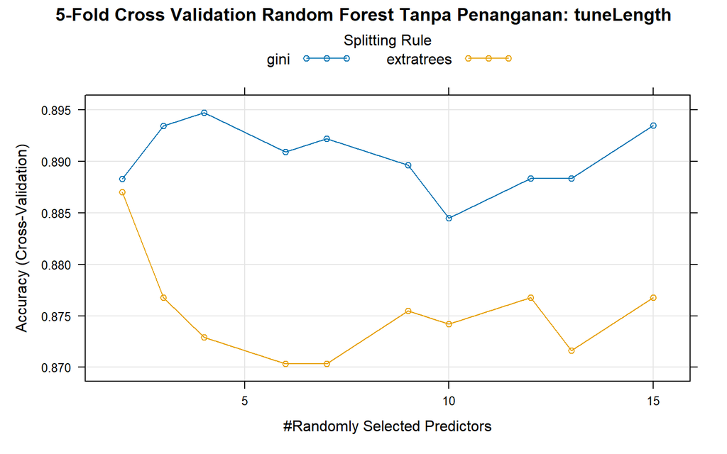

```r
plot(random_forest, main = "5-Fold Cross Validation Random Forest Tanpa Penanganan: tuneLength")
```

```r
random_forest_best <- random_forest$bestTune
random_forest_best
```

```
##   mtry splitrule min.node.size
## 5    4      gini             1
```

### Re-Fit Model Menggunakan Tuning Parameter Terbaik

```r
set.seed(123)
random_forest <- train(Experience_Level~ .,
            data = trainData,
            method = 'ranger',
            tuneGrid  = random_forest_best ,
            importance = "impurity",
            verbose = FALSE)
random_forest
```

```
## Random Forest
##
## 779 samples
##  13 predictor
##   3 classes: 'Beginner', 'Expert', 'Intermediate'
##
## No pre-processing
## Resampling: Bootstrapped (25 reps)
## Summary of sample sizes: 779, 779, 779, 779, 779, 779, ...
## Resampling results:
##
##   Accuracy   Kappa
##   0.8824072  0.8141991
##
## Tuning parameter 'mtry' was held constant at a value of 4
## Tuning
##  parameter 'splitrule' was held constant at a value of gini
## Tuning
##  parameter 'min.node.size' was held constant at a value of 1
```

```r
rf_result <- random_forest$results
rf_result
```

```
##   mtry splitrule min.node.size  Accuracy     Kappa AccuracySD    KappaSD
## 1    4      gini             1 0.8824072 0.8141991 0.01588469 0.02530419
```

```r
set.seed(123)
rf_mod<-randomForest(Experience_Level~., data = trainData, mtry=4)
rf_mod
```

```
##
## Call:
##  randomForest(formula = Experience_Level ~ ., data = trainData,      mtry = 4)
##                Type of random forest: classification
##                      Number of trees: 500
## No. of variables tried at each split: 4
##
##         OOB estimate of  error rate: 10.27%
## Confusion matrix:
##              Beginner Expert Intermediate class.error
## Beginner          230      0           71  0.23588040
## Expert              0    153            0  0.00000000
## Intermediate        9      0          316  0.02769231
```

### Akurasi

```r
eval_test_data <- function(model) {
  pred <- predict(model, newdata = testData)
  confusion_matrix <- confusionMatrix(pred, testData$Experience_Level)
  Accuracy <- confusion_matrix$overall["Accuracy"]
  Kappa <- confusion_matrix$overall["Kappa"]
  return(c(Accuracy, Kappa))
}

rf_eval <- eval_test_data(random_forest)
rf_eval
```

```
##  Accuracy     Kappa
## 0.8865979 0.8214973
```

### Peubah Penting

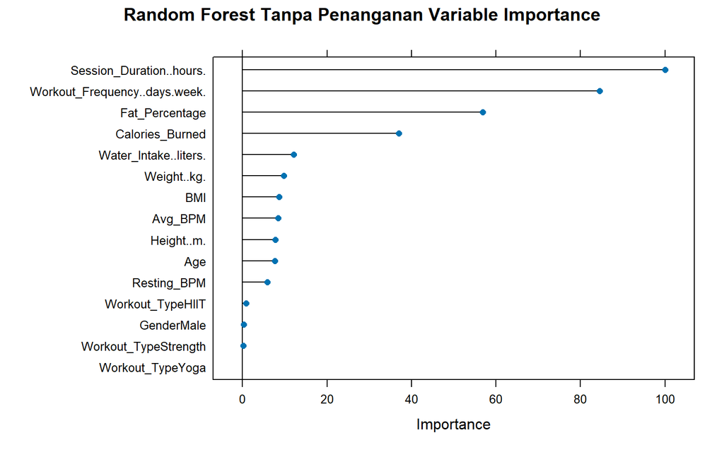

```r
plot(varImp(random_forest),
     main = "Random Forest Tanpa Penanganan Variable Importance" )
```

## Gradient Boosting

### Cross Validation

```r
set.seed(123)
boost <- train(Experience_Level ~.,
               data=trainData,
               method="gbm",
               tuneLength = 10,
               trControl=fitControl,
               verbose = FALSE)
boost
```

```
## Stochastic Gradient Boosting
##
## 779 samples
##  13 predictor
##   3 classes: 'Beginner', 'Expert', 'Intermediate'
##
## No pre-processing
## Resampling: Cross-Validated (5 fold)
## Summary of sample sizes: 624, 623, 623, 623, 623
## Resampling results across tuning parameters:
##
##   interaction.depth  n.trees  Accuracy   Kappa
##    1                  50      0.8973284  0.8382546
##    1                 100      0.8870637  0.8224442
##    1                 150      0.8883457  0.8245085
```

[output cut: 104 more lines]

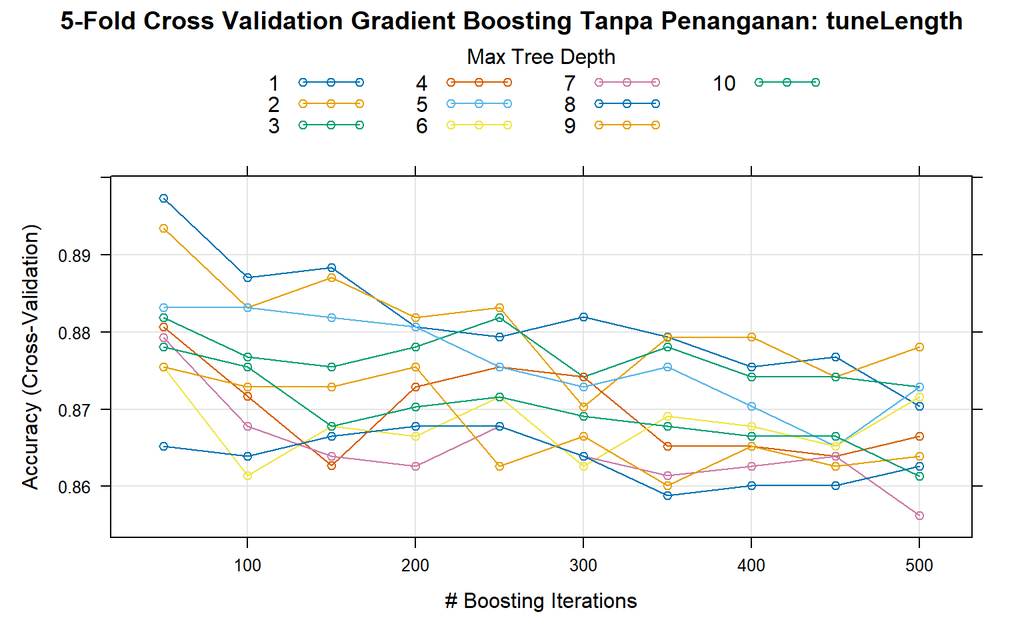

```r
plot(boost, main = "5-Fold Cross Validation Gradient Boosting Tanpa Penanganan: tuneLength")
```

```r
boost_best <- boost$bestTune
boost_best
```

```
##   n.trees interaction.depth shrinkage n.minobsinnode
## 1      50                 1       0.1             10
```

Berdasarkan output di atas, tuning parameter terbaik adalah n.trees = 50, interaction.depth = 1, shrinkage = 0.1 dan n.minobsinnode = 10, yang memberikan Accuracy = 0.8973284 dan Kappa = 0.8382546

### Re-Fit Model Menggunakan Tuning Parameter Terbaik

```r
set.seed(123)
boost <- train(Experience_Level ~.,
               data=trainData,
               method="gbm",
               tuneGrid  = boost_best,
               verbose = FALSE)
boost
```

```
## Stochastic Gradient Boosting
##
## 779 samples
##  13 predictor
##   3 classes: 'Beginner', 'Expert', 'Intermediate'
##
## No pre-processing
## Resampling: Bootstrapped (25 reps)
## Summary of sample sizes: 779, 779, 779, 779, 779, 779, ...
## Resampling results:
##
##   Accuracy   Kappa
##   0.8879424  0.8227961
##
## Tuning parameter 'n.trees' was held constant at a value of 50
## Tuning
##
## Tuning parameter 'shrinkage' was held constant at a value of 0.1
##
## Tuning parameter 'n.minobsinnode' was held constant at a value of 10
```

```r
boost_result <- boost$results
boost_result
```

```
##   n.trees interaction.depth shrinkage n.minobsinnode  Accuracy     Kappa
## 1      50                 1       0.1             10 0.8879424 0.8227961
##   AccuracySD    KappaSD
## 1 0.01680398 0.02679871
```

Diperoleh Accuracy = 0.8879424 dan Kappa = 0.8227961

### Evaluasi Terhadap Data Test

```r
boost_eval <- eval_test_data(boost)
boost_eval
```

```
##  Accuracy     Kappa
## 0.9020619 0.8457224
```

Diperoleh Accuracy sebesar 0.9020619

### Variable Importance

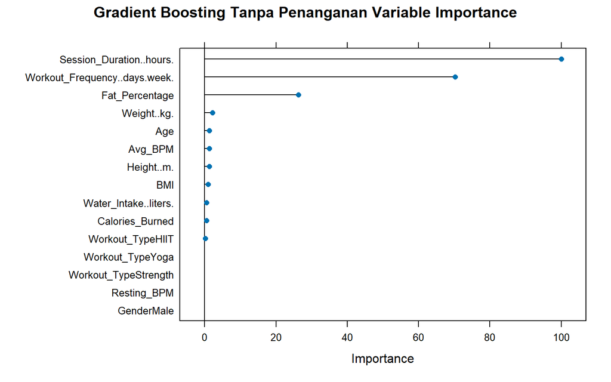

```r
plot(varImp(boost),
     main = "Gradient Boosting Tanpa Penanganan Variable Importance" )
```

# SMOTE

```r
# smote for multinomial classification
smote_data <- SmoteClassif(form = Experience_Level~ .,
                                dat = trainData,
                                C.perc = "balance",
                                dist = "HVDM")
table(smote_data$Experience_Level)
```

```
##
##     Beginner       Expert Intermediate
##          260          260          260
```

## Random Forest

### Cross Validation

```r
set.seed(123)
rf_smote <- train(Experience_Level~ .,
            data = smote_data,
            method = 'ranger',
            tuneLength = 10,
            importance = "impurity",
            trControl = fitControl,
            verbose = FALSE)
rf_smote
```

```
## Random Forest
##
## 780 samples
##  13 predictor
##   3 classes: 'Beginner', 'Expert', 'Intermediate'
##
## No pre-processing
## Resampling: Cross-Validated (5 fold)
## Summary of sample sizes: 624, 624, 624, 624, 624
## Resampling results across tuning parameters:
##
##   mtry  splitrule   Accuracy   Kappa
##    2    gini        0.9038462  0.8557692
##    2    extratrees  0.9025641  0.8538462
##    3    gini        0.9102564  0.8653846
##    3    extratrees  0.9025641  0.8538462
##    4    gini        0.9064103  0.8596154
##    4    extratrees  0.9038462  0.8557692
##    6    gini        0.9064103  0.8596154
##    6    extratrees  0.9000000  0.8500000
##    7    gini        0.9038462  0.8557692
##    7    extratrees  0.9025641  0.8538462
##    9    gini        0.9000000  0.8500000
##    9    extratrees  0.8987179  0.8480769
##   10    gini        0.9012821  0.8519231
##   10    extratrees  0.9025641  0.8538462
##   12    gini        0.9064103  0.8596154
##   12    extratrees  0.9038462  0.8557692
##   13    gini        0.9025641  0.8538462
##   13    extratrees  0.8987179  0.8480769
##   15    gini        0.9025641  0.8538462
##   15    extratrees  0.8948718  0.8423077
##
## Tuning parameter 'min.node.size' was held constant at a value of 1
## Accuracy was used to select the optimal model using the largest value.
## The final values used for the model were mtry = 3, splitrule = gini
##  and min.node.size = 1.
```

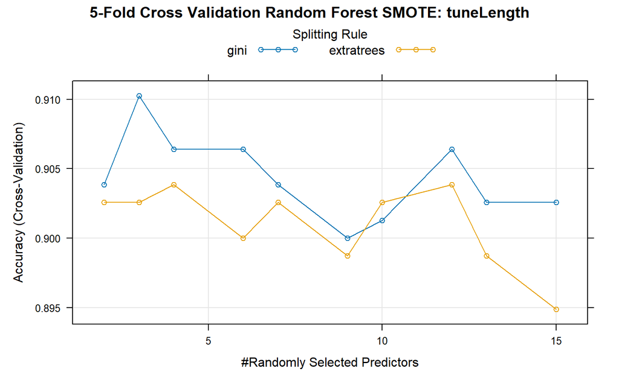

```r
plot(rf_smote, main = "5-Fold Cross Validation Random Forest SMOTE: tuneLength")
```

```r
rf_smote_best <- rf_smote$bestTune
rf_smote_best
```

```
##   mtry splitrule min.node.size
## 3    3      gini             1
```

```r
set.seed(123)
rf_smote <- train(Experience_Level~ .,
            data = smote_data,
            method = 'ranger',
            tuneGrid  = rf_smote_best,
            importance = "impurity",
            verbose = FALSE)
rf_smote
```

```
## Random Forest
##
## 780 samples
##  13 predictor
##   3 classes: 'Beginner', 'Expert', 'Intermediate'
##
## No pre-processing
## Resampling: Bootstrapped (25 reps)
## Summary of sample sizes: 780, 780, 780, 780, 780, 780, ...
## Resampling results:
##
##   Accuracy   Kappa
##   0.9024424  0.8533721
##
## Tuning parameter 'mtry' was held constant at a value of 3
## Tuning
##  parameter 'splitrule' was held constant at a value of gini
## Tuning
##  parameter 'min.node.size' was held constant at a value of 1
```

```r
rf_smote_result <- rf_smote$results
rf_smote_result
```

```
##   mtry splitrule min.node.size  Accuracy     Kappa AccuracySD    KappaSD
## 1    3      gini             1 0.9024424 0.8533721 0.01317994 0.02032963
```

```r
set.seed(123)
rf_mod4<-randomForest(Experience_Level~., data = smote_data, mtry=4)
rf_mod4
```

```
##
## Call:
##  randomForest(formula = Experience_Level ~ ., data = smote_data,      mtry = 4)
##                Type of random forest: classification
##                      Number of trees: 500
## No. of variables tried at each split: 4
##
##         OOB estimate of  error rate: 9.23%
## Confusion matrix:
##              Beginner Expert Intermediate class.error
## Beginner          202      0           58  0.22307692
## Expert              0    260            0  0.00000000
## Intermediate       14      0          246  0.05384615
```

### Akurasi

```r
rf_smote_eval <- eval_test_data(rf_smote)
rf_smote_eval
```

```
##  Accuracy     Kappa
## 0.9020619 0.8458772
```

### Peubah Penting

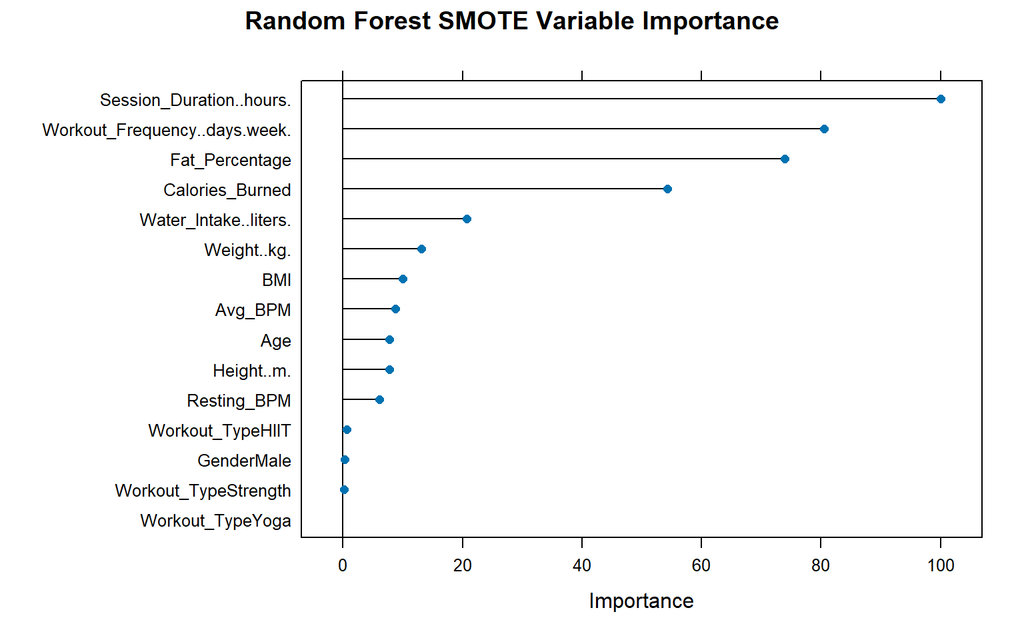

```r
plot(varImp(rf_smote),
     main = "Random Forest SMOTE Variable Importance" )
```

## Gradien Boosting

### Cross Validation

```r
set.seed(123)
boost_smote <- train(Experience_Level  ~.,
               data=smote_data,
               method="gbm",
               tuneLength = 10,
               trControl=fitControl,
               verbose = FALSE)
boost_smote
```

```
## Stochastic Gradient Boosting
##
## 780 samples
##  13 predictor
##   3 classes: 'Beginner', 'Expert', 'Intermediate'
##
## No pre-processing
## Resampling: Cross-Validated (5 fold)
## Summary of sample sizes: 624, 624, 624, 624, 624
## Resampling results across tuning parameters:
##
##   interaction.depth  n.trees  Accuracy   Kappa
##    1                  50      0.9025641  0.8538462
##    1                 100      0.8923077  0.8384615
##    1                 150      0.8756410  0.8134615
```

[output cut: 104 more lines]

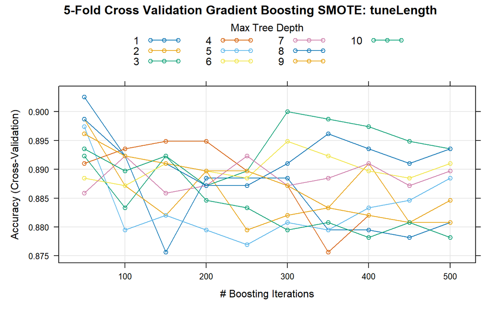

```r
plot(boost_smote, main = "5-Fold Cross Validation Gradient Boosting SMOTE: tuneLength")
```

```r
boost_smote_best <- boost_smote$bestTune
boost_smote_best
```

```
##   n.trees interaction.depth shrinkage n.minobsinnode
## 1      50                 1       0.1             10
```

### Re-Fit Model Menggunakan Tuning Parameter Terbaik

```r
set.seed(123)
boost_smote <- train(Experience_Level  ~.,
               data=smote_data,
               method="gbm",
               tuneGrid  = boost_smote_best,
               verbose = FALSE)
boost_smote
```

```
## Stochastic Gradient Boosting
##
## 780 samples
##  13 predictor
##   3 classes: 'Beginner', 'Expert', 'Intermediate'
##
## No pre-processing
## Resampling: Bootstrapped (25 reps)
## Summary of sample sizes: 780, 780, 780, 780, 780, 780, ...
## Resampling results:
##
##   Accuracy   Kappa
##   0.9073302  0.8607419
##
## Tuning parameter 'n.trees' was held constant at a value of 50
## Tuning
##
## Tuning parameter 'shrinkage' was held constant at a value of 0.1
##
## Tuning parameter 'n.minobsinnode' was held constant at a value of 10
```

```r
boost_smote_result <- boost_smote$results
boost_smote_result
```

```
##   n.trees interaction.depth shrinkage n.minobsinnode  Accuracy     Kappa
## 1      50                 1       0.1             10 0.9073302 0.8607419
##   AccuracySD    KappaSD
## 1 0.01379286 0.02087332
```

### Evaluasi Data Test

```r
boost_smote_eval <- eval_test_data(boost_smote)
boost_smote_eval
```

```
##  Accuracy     Kappa
## 0.8917526 0.8296538
```

### Variabel Important

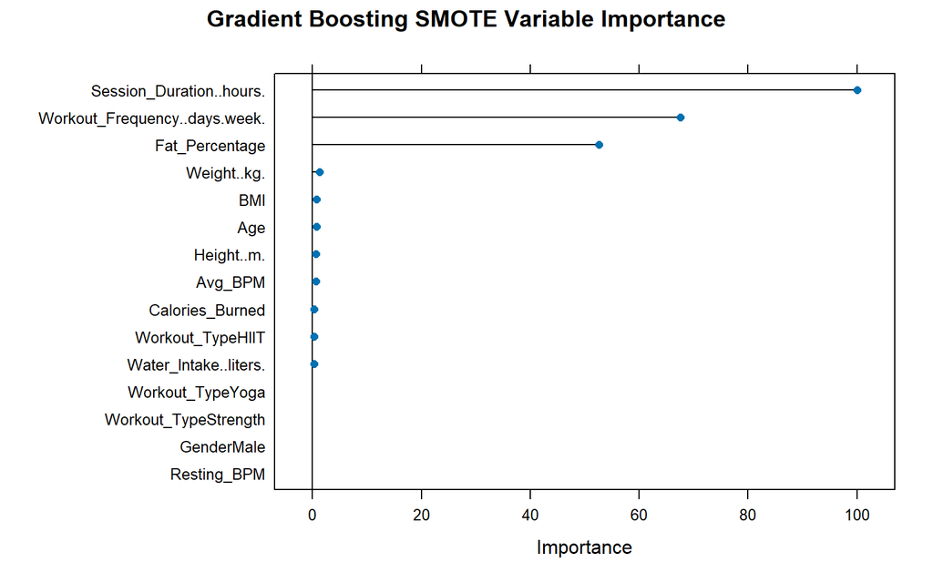

```r
plot(varImp(boost_smote),
     main = "Gradient Boosting SMOTE Variable Importance" )
```

# Oversampling

```r
# Upsample for multinomial classification
set.seed(123)
over_data <- upSample(x = trainData[, -c(13)], y = trainData$Experience_Level, yname = "Experience_Level")
table(over_data$Experience_Level)
```

```
##
##     Beginner       Expert Intermediate
##          325          325          325
```

## Random Forest

### Cross Validation

```r
set.seed(123)
rf_over <- train(Experience_Level~ .,
            data = over_data,
            method = 'ranger',
            tuneLength = 10,
            importance = "impurity",
            trControl = fitControl,
            verbose = FALSE)
rf_over
```

```
## Random Forest
##
## 975 samples
##  13 predictor
##   3 classes: 'Beginner', 'Expert', 'Intermediate'
##
## No pre-processing
## Resampling: Cross-Validated (5 fold)
## Summary of sample sizes: 780, 780, 780, 780, 780
## Resampling results across tuning parameters:
##
##   mtry  splitrule   Accuracy   Kappa
##    2    gini        0.9056410  0.8584615
##    2    extratrees  0.9015385  0.8523077
##    3    gini        0.9107692  0.8661538
##    3    extratrees  0.9097436  0.8646154
##    4    gini        0.9138462  0.8707692
##    4    extratrees  0.9005128  0.8507692
##    6    gini        0.9117949  0.8676923
##    6    extratrees  0.9035897  0.8553846
##    7    gini        0.9169231  0.8753846
##    7    extratrees  0.9076923  0.8615385
##    9    gini        0.9097436  0.8646154
##    9    extratrees  0.9015385  0.8523077
##   10    gini        0.9138462  0.8707692
##   10    extratrees  0.9015385  0.8523077
##   12    gini        0.9107692  0.8661538
##   12    extratrees  0.8994872  0.8492308
##   13    gini        0.9138462  0.8707692
##   13    extratrees  0.8984615  0.8476923
##   15    gini        0.9097436  0.8646154
##   15    extratrees  0.8984615  0.8476923
##
## Tuning parameter 'min.node.size' was held constant at a value of 1
## Accuracy was used to select the optimal model using the largest value.
## The final values used for the model were mtry = 7, splitrule = gini
##  and min.node.size = 1.
```

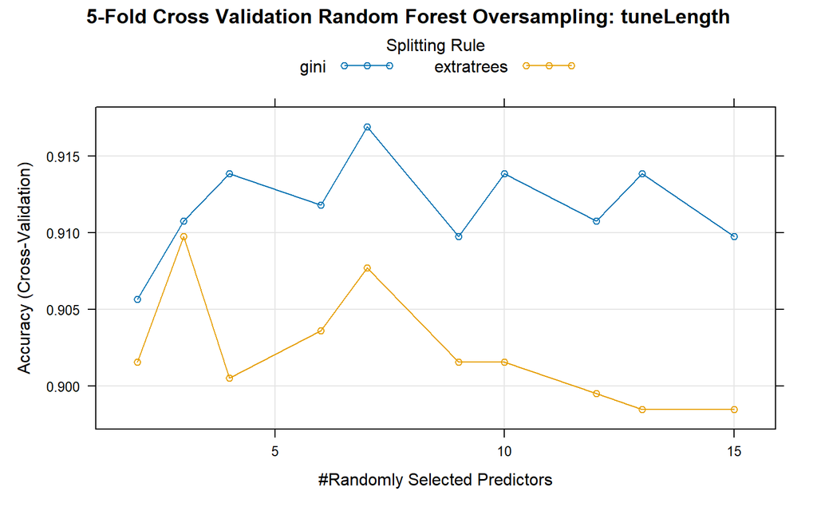

```r
plot(rf_over, main = "5-Fold Cross Validation Random Forest Oversampling: tuneLength")
```

```r
rf_over_best <- rf_over$bestTune
rf_over_best
```

```
##   mtry splitrule min.node.size
## 9    7      gini             1
```

### Re Fit Model

```r
set.seed(123)
rf_over <- train(Experience_Level~ .,
            data = over_data,
            method = 'ranger',
            tuneGrid  = rf_over_best,
            importance = "impurity",
            verbose = FALSE)
rf_over
```

```
## Random Forest
##
## 975 samples
##  13 predictor
##   3 classes: 'Beginner', 'Expert', 'Intermediate'
##
## No pre-processing
## Resampling: Bootstrapped (25 reps)
## Summary of sample sizes: 975, 975, 975, 975, 975, 975, ...
## Resampling results:
##
##   Accuracy   Kappa
##   0.9088917  0.8632607
##
## Tuning parameter 'mtry' was held constant at a value of 7
## Tuning
##  parameter 'splitrule' was held constant at a value of gini
## Tuning
##  parameter 'min.node.size' was held constant at a value of 1
```

```r
rf_over_result <- rf_over$results
rf_over_result
```

```
##   mtry splitrule min.node.size  Accuracy     Kappa AccuracySD  KappaSD
## 1    7      gini             1 0.9088917 0.8632607 0.01045552 0.015663
```

```r
set.seed(123)
rf_mod2<-randomForest(Experience_Level~., data = over_data, mtry=7)
rf_mod2
```

```
##
## Call:
##  randomForest(formula = Experience_Level ~ ., data = over_data,      mtry = 7)
##                Type of random forest: classification
##                      Number of trees: 500
## No. of variables tried at each split: 7
##
##         OOB estimate of  error rate: 8%
## Confusion matrix:
##              Beginner Expert Intermediate class.error
## Beginner          261      0           64  0.19692308
## Expert              0    325            0  0.00000000
## Intermediate       14      0          311  0.04307692
```

### Akurasi data Test

```r
rf_over_eval <- eval_test_data(rf_over)
rf_over_eval
```

```
##  Accuracy     Kappa
## 0.8917526 0.8295683
```

### Variabel Important

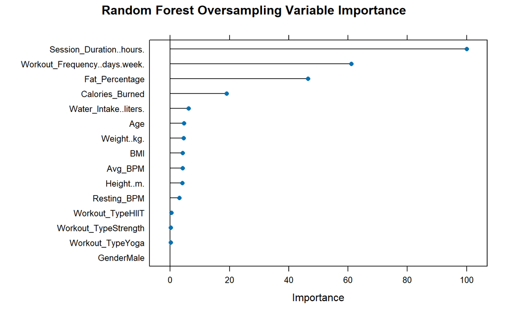

```r
plot(varImp(rf_over),
     main = "Random Forest Oversampling Variable Importance" )
```

## Gradient Boosting

### Cross Validation

```r
set.seed(123)
boost_over <- train(Experience_Level~.,
               data=over_data,
               method="gbm",
               tuneLength = 10,
               trControl=fitControl,
               verbose = FALSE)
boost_over
```

```
## Stochastic Gradient Boosting
##
## 975 samples
##  13 predictor
##   3 classes: 'Beginner', 'Expert', 'Intermediate'
##
## No pre-processing
## Resampling: Cross-Validated (5 fold)
## Summary of sample sizes: 780, 780, 780, 780, 780
## Resampling results across tuning parameters:
##
##   interaction.depth  n.trees  Accuracy   Kappa
##    1                  50      0.9097436  0.8646154
##    1                 100      0.9015385  0.8523077
##    1                 150      0.8892308  0.8338462
```

[output cut: 104 more lines]

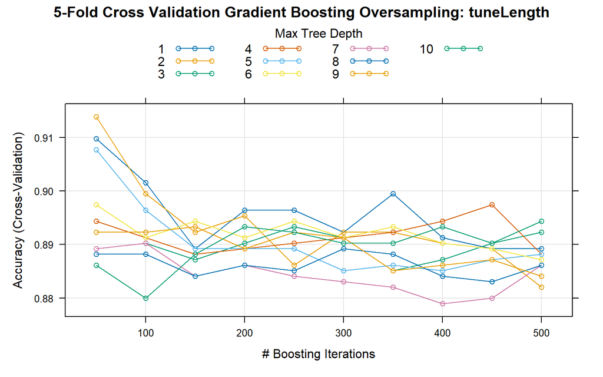

```r
plot(boost_over, main = "5-Fold Cross Validation Gradient Boosting Oversampling: tuneLength")
```

```r
boost_over_best <- boost_over$bestTune
boost_over_best
```

```
##    n.trees interaction.depth shrinkage n.minobsinnode
## 11      50                 2       0.1             10
```

### Re fit Model

```r
set.seed(123)
boost_over <- train(Experience_Level ~.,
               data=over_data,
               method="gbm",
               tuneGrid  = boost_over_best,
               verbose = FALSE)
boost_over
```

```
## Stochastic Gradient Boosting
##
## 975 samples
##  13 predictor
##   3 classes: 'Beginner', 'Expert', 'Intermediate'
##
## No pre-processing
## Resampling: Bootstrapped (25 reps)
## Summary of sample sizes: 975, 975, 975, 975, 975, 975, ...
## Resampling results:
##
##   Accuracy   Kappa
##   0.8994198  0.8489845
##
## Tuning parameter 'n.trees' was held constant at a value of 50
## Tuning
##
## Tuning parameter 'shrinkage' was held constant at a value of 0.1
##
## Tuning parameter 'n.minobsinnode' was held constant at a value of 10
```

```r
boost_over_result <- boost_over$results
boost_over_result
```

```
##   n.trees interaction.depth shrinkage n.minobsinnode  Accuracy     Kappa
## 1      50                 2       0.1             10 0.8994198 0.8489845
##   AccuracySD    KappaSD
## 1 0.01453288 0.02178931
```

### Akurasi data Test

```r
boost_over_eval <- eval_test_data(boost_over)
boost_over_eval
```

```
##  Accuracy     Kappa
## 0.8969072 0.8377248
```

### Variable Importan

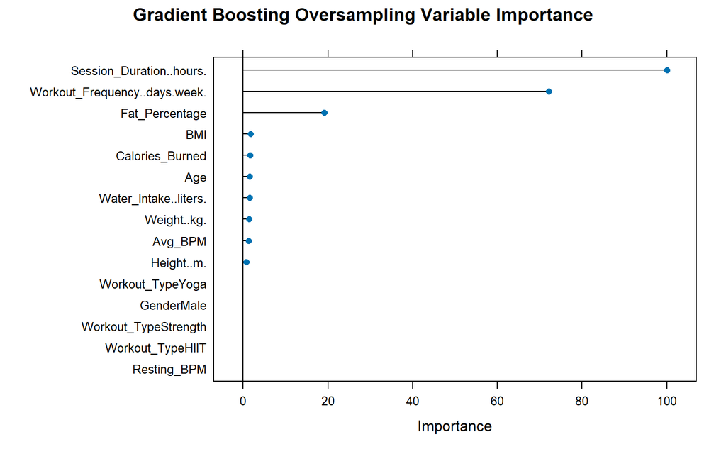

```r
plot(varImp(boost_over),
     main = "Gradient Boosting Oversampling Variable Importance" )
```

# Undersampling

```r
set.seed(123)
under_data <- downSample(x = trainData[, -c(13)], y = trainData$Experience_Level, yname = "Experience_Level")
table(under_data$Experience_Level)
```

```
##
##     Beginner       Expert Intermediate
##          153          153          153
```

## Random Forest

### Cross Validation

```r
set.seed(123)
rf_under <- train(Experience_Level~ .,
            data = under_data,
            method = 'ranger',
            tuneLength = 10,
            importance = "impurity",
            trControl = fitControl,
            verbose = FALSE)
rf_under
```

```
## Random Forest
##
## 459 samples
##  13 predictor
##   3 classes: 'Beginner', 'Expert', 'Intermediate'
##
## No pre-processing
## Resampling: Cross-Validated (5 fold)
## Summary of sample sizes: 367, 368, 366, 368, 367
## Resampling results across tuning parameters:
##
##   mtry  splitrule   Accuracy   Kappa
##    2    gini        0.8605279  0.7909239
##    2    extratrees  0.8693441  0.8041174
##    3    gini        0.8540296  0.7811652
##    3    extratrees  0.8540072  0.7811550
##    4    gini        0.8562035  0.7844294
##    4    extratrees  0.8539355  0.7810584
##    6    gini        0.8474600  0.7713104
##    6    extratrees  0.8583550  0.7876933
##    7    gini        0.8605991  0.7909878
##    7    extratrees  0.8561572  0.7843718
##    9    gini        0.8518795  0.7779370
##    9    extratrees  0.8583311  0.7876572
##   10    gini        0.8519029  0.7779526
##   10    extratrees  0.8539355  0.7810291
##   12    gini        0.8541480  0.7813211
##   12    extratrees  0.8627029  0.7941899
##   13    gini        0.8497051  0.7746621
##   13    extratrees  0.8627029  0.7941906
##   15    gini        0.8540535  0.7811784
##   15    extratrees  0.8605051  0.7908887
##
## Tuning parameter 'min.node.size' was held constant at a value of 1
## Accuracy was used to select the optimal model using the largest value.
## The final values used for the model were mtry = 2, splitrule = extratrees
##  and min.node.size = 1.
```

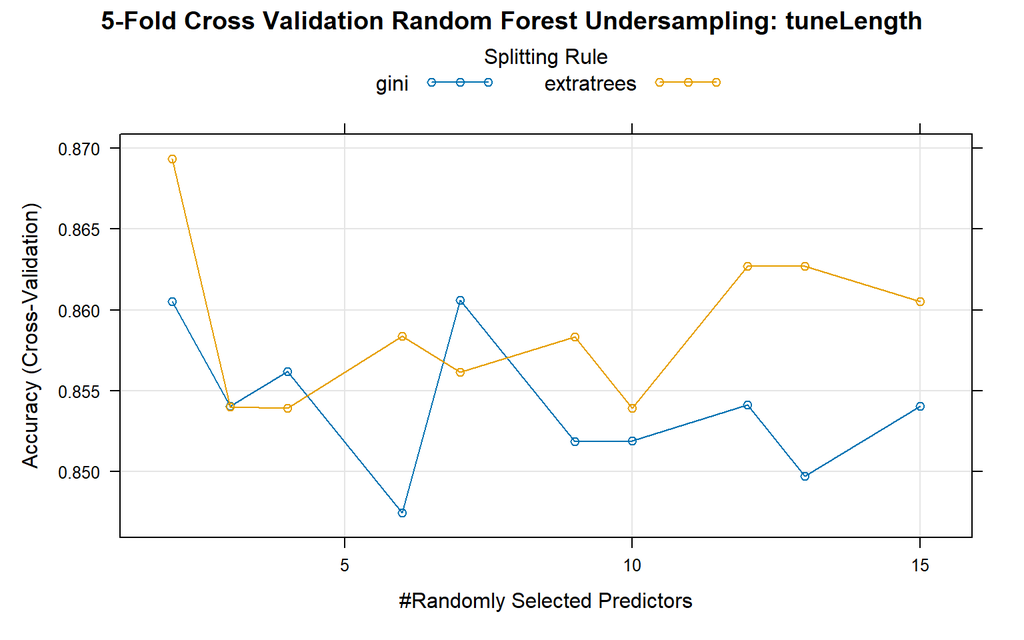

```r
plot(rf_under, main = "5-Fold Cross Validation Random Forest Undersampling: tuneLength")
```

```r
rf_under_best <- rf_under$bestTune
rf_under_best
```

```
##   mtry  splitrule min.node.size
## 2    2 extratrees             1
```

```r
set.seed(123)
rf_under <- train(Experience_Level ~ .,
            data = under_data,
            method = 'ranger',
            tuneGrid  = rf_under_best,
            importance = "impurity",
            verbose = FALSE)
rf_under
```

```
## Random Forest
##
## 459 samples
##  13 predictor
##   3 classes: 'Beginner', 'Expert', 'Intermediate'
##
## No pre-processing
## Resampling: Bootstrapped (25 reps)
## Summary of sample sizes: 459, 459, 459, 459, 459, 459, ...
## Resampling results:
##
##   Accuracy   Kappa
##   0.8511252  0.7760419
##
## Tuning parameter 'mtry' was held constant at a value of 2
## Tuning
##  parameter 'splitrule' was held constant at a value of extratrees
##
## Tuning parameter 'min.node.size' was held constant at a value of 1
```

```r
rf_under_result <- rf_under$results
rf_under_result
```

```
##   mtry  splitrule min.node.size  Accuracy     Kappa AccuracySD    KappaSD
## 1    2 extratrees             1 0.8511252 0.7760419 0.02075786 0.03101936
```

```r
set.seed(123)
rf_mod3<-randomForest(Experience_Level ~., data = under_data, mtry=2)
rf_mod3
```

```
##
## Call:
##  randomForest(formula = Experience_Level ~ ., data = under_data,      mtry = 2)
##                Type of random forest: classification
##                      Number of trees: 500
## No. of variables tried at each split: 2
##
##         OOB estimate of  error rate: 14.6%
## Confusion matrix:
##              Beginner Expert Intermediate class.error
## Beginner          115      0           38   0.2483660
## Expert              0    153            0   0.0000000
## Intermediate       29      0          124   0.1895425
```

### Akurasi Test

```r
rf_under_eval <- eval_test_data(rf_under)
rf_under_eval
```

```
##  Accuracy     Kappa
## 0.8814433 0.8139903
```

### Plot Variabel Important

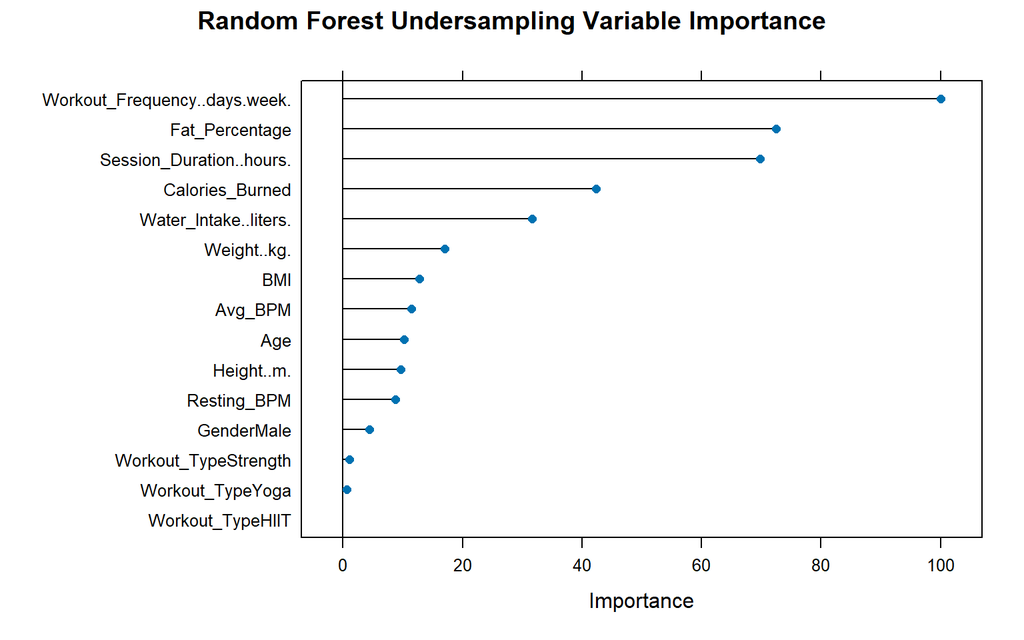

```r
plot(varImp(rf_under),
     main = "Random Forest Undersampling Variable Importance" )
```